# The Empty Chair

Quantifying and Reducing the Cost of Patient No-Shows Across a UK Private Clinic Network

Author

Weston Nyabeze | MS Business Analytics and AI, Kogod School of Business, American University

Abstract

A ten-page executive edition of the full technical no-show analysis. It states the size of the loss, the three operational factors that drive it, how the predictive model was built and validated, and a costed four-part action plan. The full technical report, with the complete data audit, four-model bake-off and 41 supporting exhibits, is the companion document to this one.

## Executive summary

Exhibit 1. Headline measures, FY2026 booking year

| Measure | Value and basis |
| --- | --- |
| Appointments analysed | **10,000** : 2,890 patients across 5 sites |
| No-show rate | **21.4%** : 1 in every 4.7 appointments |
| Gross economic exposure | **£298,813** : fees £221,343 plus idle staff £77,470 |
| Slots recovered by rebooking | **41.5%** : 890 of 2,143 missed slots refilled |
| Net economic loss | **£206,896** : gross exposure net of rebooking recovery |
| Net loss per appointment booked | **£20.69** : the figure that belongs in the operating budget |

This report answers one question for the clinic network’s leadership: **why are appointments being missed, and what is it worth to fix that?** A five-site network booked 10,000 appointments in the year covered by this extract, and 21.4% of them, one in every 4.7, went unattended. After crediting back the slots that were successfully rebooked, that leaves £206,896 of real economic loss a year, or £20.69 on every single appointment the network takes.

No-show risk here is driven by three things the clinic already controls: **how far ahead an appointment is booked**, **how the reminder programme is run**, and **whether a cancelled slot is released back into the booking system**. It is not driven by who the patient is: age, gender, clinic site and day of week make essentially no difference. A predictive model built from the operational factors ranks appointments by risk well enough to make a targeted call programme profitable, and a costed four-part action plan below recovers a substantial share of the loss, most of it starting next quarter with no pilot required.

> **How to read this report.** It has been deliberately shortened to ten pages for a general business audience. Every figure quoted is calculated directly from the underlying data by the code that also produced the reader’s copy of this document, not typed in by hand, so every number here can be traced back to its source. A companion technical report covers the full statistical detail, including 41 supporting exhibits, for readers who want it.

# The data behind this report

Before analysing anything, the ten-thousand-row booking file was checked for problems, because a model is only as trustworthy as what it is built on. Three issues were found and corrected. Two columns that were supposed to record each patient’s history of missed appointments turn out to be completely empty (1 distinct value across all 10,000 rows), so this analysis cannot flag “a patient who has a habit of missing appointments”, only “an appointment that looks risky right now,” which turns out to matter more in practice. Three financial columns (money lost, staff time wasted, whether the slot was rebooked) are calculated directly from whether the appointment was missed; using them to *predict* a no-show would be circular reasoning, so they are used only to size the loss in pounds, never to feed the model. Finally, the reminder-tracking fields overlapped in a way that would have broken the statistics if left as supplied, so they were consolidated into one clean signal. None of this changes the conclusions; it is what makes the conclusions trustworthy.

# Sizing the loss

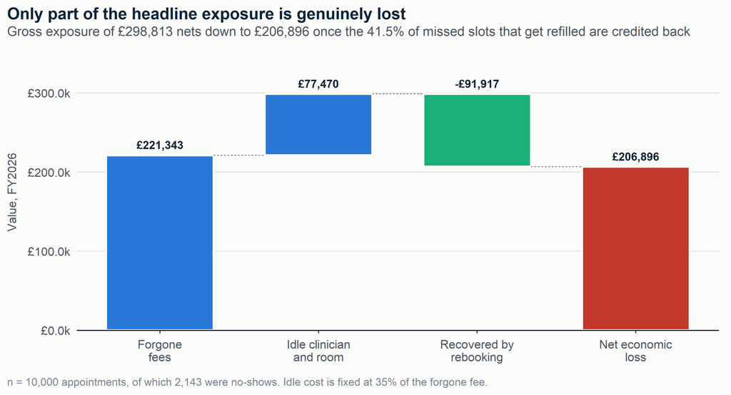

Figure 1: Exhibit 2. From gross fee exposure to net economic loss. Rebooking recovers a meaningful share of forgone fees, but the idle-staff charge is incurred whether or not the slot is refilled.

The headline figure of £221,343 in lost fees is the wrong number to plan around, in two directions at once. It understates the true cost because every missed appointment also strands a clinician and a room, adding £77,470 in idle time. It overstates the true cost because 41.5% of missed slots get filled by another patient, so that fee is not actually lost. Netting both adjustments gives £206,896, or £20.69 per appointment booked. That per-appointment figure is the one that matters for planning, because it is the one that scales correctly if the network grows: it stays true whether the network books ten thousand appointments a year or twenty thousand, while the lump-sum total does not.

Loss is not spread evenly. The *rate* of no-shows barely differs across the four service lines, but the *cost* of a no-show does, because a missed dermatology appointment carries a higher fee than a missed GP appointment. A prevention budget spent in proportion to failure rate would therefore waste money; spent in proportion to pounds at risk, it goes where it is worth most. That is how the targeting model described below is scored.

# What drives it

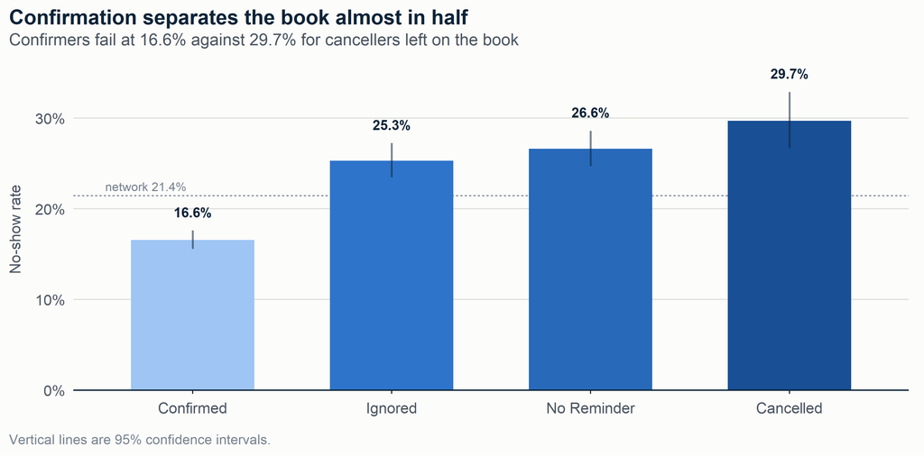

Figure 2: Exhibit 3. No-show rate by how the patient responded to their reminder. The gap is large, but because patients choose whether to confirm, it is an upper bound on what a confirmation campaign could achieve, not a clean effect estimate.

Three operational factors carry almost all of the explanatory power. **Booking lead time**: 26.0% of appointments made 22 or more days out are missed, against 16.4% for those booked within three days, and risk rises step by step in between. **Reminder confirmation**, shown above: patients who confirm miss 16.6% of appointments; patients who cancel but are left on the book anyway miss 29.7%. That gap is real but partly reflects who bothers to confirm, not just what confirming does, so it is used here for targeting rather than as a promised effect. **Reminder timing** is the cleaner result: because reminders are sent at 24, 48 or 72 hours in roughly equal numbers regardless of patient type, a 72-hour reminder is associated with a 2.6 pp lower no-show rate than a 24 or 48-hour one (p = 0.0063), and this one comes closest to a genuine cause-and-effect finding, since the clinic assigns the timing, not the patient.

Two findings are worth flagging precisely because they run against instinct. Patients with a chronic condition on file are *more* reliable attenders, not less (16.2% versus 23.6%, odds ratio 0.62), because an ongoing treatment relationship gives them a reason to show up. And several plausible levers turn out not to matter at all: a second reminder message changes the no-show rate by only 0.5 pp, statistically indistinguishable from zero, and neither clinic site nor day of week nor patient age moves risk in any usable way. Reporting a null result is as valuable as reporting a real one, because it says where *not* to spend.

# Building the model

A single prediction is not enough, because a clinic can act on risk at two different moments with two different sets of information: at the moment the appointment is booked, and again in the 24 to 72 hours before it, once the reminder response is known. Two versions of the model were built to match those two moments.

Every patient’s appointments were kept together in only one of three groups: a training group to fit the models, a calibration group to check and correct the models’ confidence, and a holdout group set aside untouched until the very last step, so that the final accuracy figure is a genuinely honest one. Four competing approaches were tried, from a plain, fully transparent regression up to a tuned machine-learning ensemble, each tuned by cross-validation (repeatedly testing settings against a slice of the training data itself, never against the holdout). The model that is actually deployed was chosen on the calibration group, using a formal statistical test: find the best-scoring candidate, keep every other candidate that cannot be shown to be meaningfully worse, and among those, deploy the simplest and most explainable one. That rule exists to stop the choice of model from depending on which one happened to get lucky on a single sample.

Exhibit 4. How the four candidate models performed on 2,538 appointments none of them had seen before. Logistic regression was deployed because it is not measurably worse than the top scorer and is the simplest one a person can read and check by hand.

| Model | Holdout accuracy score (AUC) | 95% confidence range | Verdict |
| --- | --- | --- | --- |
| Logistic regression | 0.634 | 0.608 to 0.660 | Deployed |
| Elastic net | 0.634 | 0.608 to 0.660 | Statistically tied |
| Random forest | 0.629 | 0.603 to 0.655 | Statistically tied |
| Gradient boosting (XGBoost) | 0.627 | 0.601 to 0.653 | Statistically tied |

The score in that table, AUC, works like this: pick one appointment at random that turned out to be a no-show and one that did not, and ask the model which it thought was riskier. A score of 50% is a coin flip; a score of 100% would mean the model is never wrong. Logistic regression scores 0.634, which is honest but modest, and it is reported on appointments and patients the model never saw during fitting, so it is not a flattered number. The notable result is that a far more sophisticated machine-learning model, tested alongside it, could not score measurably better: 3 of its 3 rivals are statistically indistinguishable from the winner. That is not a disappointing outcome, it is a finding in its own right — it means the relationship between these operational factors and attendance is simple and additive rather than hidden in complex combinations, so there is no accuracy paid up in exchange for using the version a clinician can actually read. Before its probabilities were used for anything financial, the model’s confidence was also double-checked and corrected on data set aside for exactly that purpose, so that a predicted 25% risk really does behave like roughly a one-in-four chance.

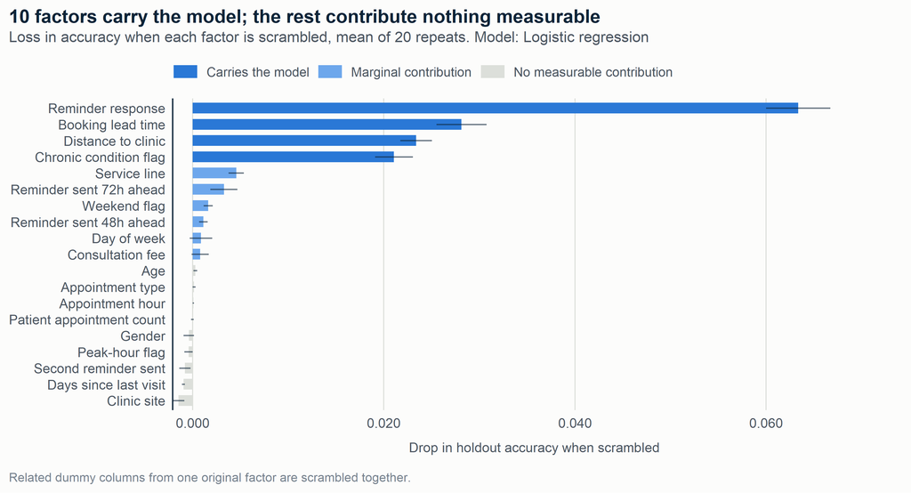

Figure 3: Exhibit 5. What actually carries the model. Each factor is scrambled in turn and the resulting drop in accuracy measured on data the model never trained on; a bigger drop means the model relies on that factor more.

# The business case

Not every classification error costs the same. A wasted outreach call is cheap; a missed appointment that goes uncontacted is expensive.

On these figures, a genuine no-show costs the clinic about £97 in lost value once idle time and rebooking are accounted for, while a phone call to a patient who was always going to attend costs about £4.00. Because those two numbers are roughly 24 to one apart, the sensible policy is not to call every patient, or the top half, or the top 5%; it is to work out, from the economics, exactly which risk score makes a call worth its cost, and stop there.

At the economically optimal cut-off, 20.0% predicted risk, the clinic would contact 52.3% of its book and catch 67.9% of the appointments that go on to be missed, for a modelled net benefit of £7,447 a year. Only about 28.5% of the calls made at that threshold turn out to be genuine no-shows, which sounds low but is not a flaw: because the value of catching a real no-show is so much larger than the cost of a wasted call, the programme is still comfortably profitable even with most calls “missing.” Two of the numbers behind that estimate, the cost of a call and how often a call actually changes a patient’s behaviour, are assumptions rather than measurements, because this dataset contains no record of anyone having actually tried the intervention. The chart below shows what happens to the business case across a wide range of both assumptions, rather than hiding that uncertainty behind a single confident figure.

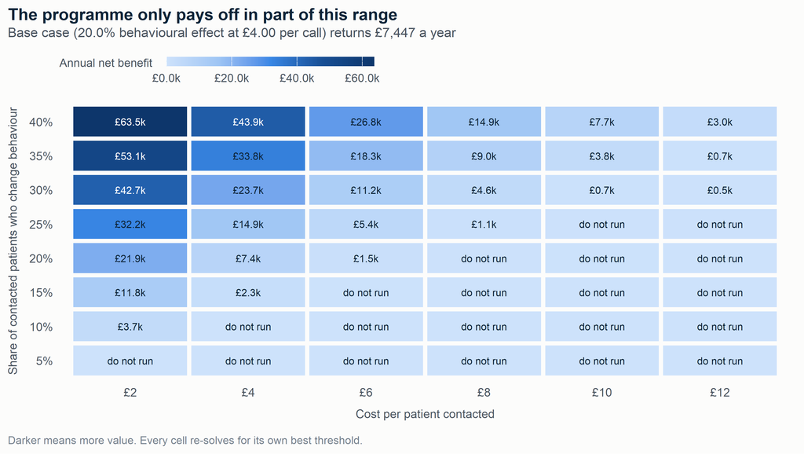

Figure 4: Exhibit 6. Modelled annual net benefit of the outreach programme, re-optimised for every combination of call cost and behavioural effect. A cell reading “do not run” means no threshold covers its costs, so the clinic is better off not calling anyone under that assumption.

# Recommendations

Exhibit 7. The recommended action plan. Combined it is worth £43,818 a year, 21.2% of the current net loss. £36,371 of that (17.6%) needs no pilot and could start next quarter.

| Play | Annual value | Annual cost | Net annual benefit |
| --- | --- | --- | --- |
| 1. Default the reminder to 72 hours ahead | £13,501 | £0 | £13,501 |
| 2. Extend reminder coverage to everyone | £12,502 | £118 | £12,384 |
| 3. Targeted outreach on the flagged tail (pilot first) | £28,377 | £20,930 | £7,447 |
| 4. Auto-release slots when a patient cancels | £12,986 | £2,500 | £10,486 |

Play 3, targeted outreach, is the only one gated behind testing, because its value depends entirely on an assumption (that a call changes 20.0% of contacted patients’ behaviour) that nothing in this dataset can confirm. Before it is scaled network-wide, it should be run as a genuine randomised trial: call half of the flagged, highest-risk appointments and leave the other half as a comparison group, then measure whether the called group actually attends more. Since only 28.5% of flagged appointments are genuine no-shows, the programme needs to move the needle by roughly 15% to break even, a real but not enormous bar to clear, and one worth testing cheaply before committing to it at scale.

# Limitations

Four caveats should travel with every number above. The dataset behind this report has the statistical fingerprints of simulated rather than real-world data (no missing values, exact arithmetic relationships between fields), so the analytical method is sound and reusable on a real extract, but the specific pounds and percentages should be treated as illustrative rather than as this network’s confirmed budget line. Two fields meant to capture each patient’s history of missed appointments are empty in this extract, so no “chronically unreliable patient” segment could be identified, only risk at the level of the individual appointment. The gap between patients who confirm and patients who ignore a reminder mixes a real effect with patients simply self-selecting, so it is used for ranking risk, never presented as a promised saving. And the whole business case rests on one figure this dataset cannot supply: how much a phone call actually changes a patient’s behaviour, which is exactly what the recommended pilot is designed to measure before real money is committed at scale.

# Conclusion

This network loses £206,896 a year to appointments that are booked, staffed and never attended, £20.69 on every appointment it takes. That loss is driven by how the clinic schedules and reminds, not by who its patients are: booking lead time, reminder timing and unreleased cancellations explain most of what can be explained, and all three are within the clinic’s own control. A model built from those factors cannot say which specific patient will miss their appointment, but it can rank appointments by risk well enough to make a targeted phone programme profitable, and the fact that a far more complex model could not beat it is itself reassuring: the relationship is simple enough to trust and cheap enough to maintain.

Put together, the four recommended changes are worth £43,818 a year, 21.2% of the current loss. The more important number is the split: £36,371 (17.6%) needs no pilot and no new evidence, only a decision to change three operational settings, while the remaining £7,447 is real money on the table conditional on a small, cheap trial confirming that outreach calls actually change behaviour. That is a deliberately modest claim next to the size of the problem, and it is the honest one: this report shows the clinic exactly how much of its no-show loss it can recover starting next quarter, and exactly what it needs to test before promising the rest.

*Reproducibility: random seed 1234568, one value governing every step above. The full technical report behind this summary, patient-level data audit, four-model bake-off with tuning detail, calibration diagnostics and 41 supporting exhibits, is available as a companion document.*